# P8105_final_Alzheimei

bl3175, cw3747, lg3450, yw4662 2025-11-27

```r
library(tidyverse)
library(patchwork)
library(scales)
library(dplyr)


knitr::opts_chunk$set(
  fig.width = 6,
  fig.asp = .6,
  out.width = "90%"
)

theme_set(theme_minimal() + theme(legend.position = "bottom"))

options(
  ggplot2.continuous.colour = "viridis",
  ggplot2.continuous.fill = "viridis"
)

scale_colour_discrete = scale_colour_viridis_d
scale_fill_discrete = scale_fill_viridis_d
```

## Data Import

```r
raw_az_data <- read.csv("data/2015-2022 Alzheimer Data.csv") |>
  janitor::clean_names()
raw_az_data <- raw_az_data[-nrow(raw_az_data), ]
```

```r
az_clean <- raw_az_data |>
  filter(
    !is.na(data_value),
    !is.na(year_start),
    !is.na(location_abbr)
  )
```

## Descriptive

```r
az_clean |>
  summarise(
    n_rows = n(),
    n_states = n_distinct(location_abbr),
    year_min = min(year_start),
    year_max = max(year_start),
    n_topics = n_distinct(topic),
    n_questions = n_distinct(question)
  )
```

```
##   n_rows n_states year_min year_max n_topics n_questions
## 1  32616       59     2015     2022       39          39
```

For this study, we focused on BRFSS items whose topic was labeled **“cognitive decline”** or **“cognitive impairment”**. These items capture self-reported cognitive problems among middle-aged and older adults, and we treat them as Alzheimer’s-related cognitive indicators rather than clinically confirmed Alzheimer’s disease.

## Data considering Alzheimer

```r
library(stringr)

az_cog <- az_clean |>
  filter(
    str_detect(topic, regex("cognitive decline|cognitive impairment",
                            ignore_case = TRUE))
  )
```

### sex and age summary

```r
az_cog_summary_base <- az_cog |>
  mutate(
    age_group = case_when(
      stratification_category1 == "Age Group" ~ stratification1,
      TRUE ~ "Overall"
    ),
    sex_group = case_when(
      stratification_category2 == "Sex" ~ stratification2,
      TRUE ~ "Overall"
    )
  )
```

### state × age × sex table

```r
az_cog_state_age_sex <- az_cog_summary_base |>
  group_by(
    location_abbr, location_desc,
    age_group,
    sex_group
  ) |>
  summarise(
    n_obs = n(),
    mean_value = mean(data_value, na.rm = TRUE),
    .groups = "drop"
  ) |>
  arrange(desc(mean_value))

az_cog_state_age_sex
```

```
## # A tibble: 448 × 6
##    location_abbr location_desc age_group         sex_group n_obs mean_value
##    <chr>         <chr>         <chr>             <chr>     <int>      <dbl>
##  1 PR            Puerto Rico   50-64 years       Female        4       59.8
##  2 PR            Puerto Rico   50-64 years       Overall       8       58.2
##  3 PR            Puerto Rico   Overall           Male          4       54.5
##  4 PR            Puerto Rico   Overall           Overall       8       53.6
##  5 PR            Puerto Rico   Overall           Female        4       52.8
##  6 PR            Puerto Rico   65 years or older Overall       8       47.9
##  7 RI            Rhode Island  50-64 years       Female        4       47.2
##  8 OK            Oklahoma      50-64 years       Female        4       46.6
##  9 DE            Delaware      50-64 years       Female        4       46.1
## 10 PR            Puerto Rico   65 years or older Female        4       44.7
## # ℹ 438 more rows
```

### top 10 states (2015-2016)

```r
az_cog_65_overall <- az_cog_summary_base |>
  filter(
    age_group == "65 years or older",
    sex_group == "Overall"
  )

nrow(az_cog_65_overall)
```

```
## [1] 609
```

```r
sort(unique(az_cog_65_overall$year_start))
```

```
## [1] 2015 2016
```

The CDC Healthy Aging dataset covers survey years 2015–2022. For topics coded as Cognitive Decline or Cognitive Impairment, data were only available in 2015–2016; therefore, our Alzheimer’s-related analyses are restricted to these two years.

```r
library(ggplot2)

az_cog_65_overall <- az_cog_summary_base |>
  filter(
    age_group == "65 years or older",
    sex_group == "Overall"
  )

years_use <- c(2015, 2016)

az_cog_65_overall_15_16 <- az_cog_65_overall |>
  filter(year_start %in% years_use)
```

```r
top10_state_15_16 <- az_cog_65_overall_15_16 |>
  group_by(location_abbr, location_desc) |>
  summarise(
    n_obs = n(),
    mean_15_16 = mean(data_value, na.rm = TRUE),
    .groups = "drop"
  ) |>
  arrange(desc(mean_15_16)) |>
  slice_head(n = 10)

top10_state_15_16
```

```
## # A tibble: 10 × 4
##    location_abbr location_desc  n_obs mean_15_16
##    <chr>         <chr>          <int>      <dbl>
##  1 PR            Puerto Rico        8       47.9
##  2 NRE           Northeast         30       33.6
##  3 OK            Oklahoma           8       31.5
##  4 MS            Mississippi       14       31.4
##  5 SOU           South             30       31.0
##  6 SD            South Dakota       8       30.9
##  7 MA            Massachusetts      5       30.8
##  8 AL            Alabama           14       30.2
##  9 AK            Alaska             7       29.8
## 10 SC            South Carolina    14       29.5
```

Using data from 2015–2016, we ranked states and regions by the mean prevalence of Alzheimer’s-related cognitive indicators among adults aged 65 years and older (all sexes combined). The highest burden was observed in Puerto Rico (mean prevalence 47.9%), which was notably higher than any U.S. state or region. The Northeast region ranked second (33.6%), followed by Oklahoma (31.5%), Mississippi (31.4%), and the South region as a whole (31.0%). The remaining states in the top ten—South Dakota, Massachusetts, Alabama, Alaska, and South Carolina—all had mean prevalences around 30%. Overall, these results suggest substantial geographic variation in self-reported cognitive problems among older adults, with several Southern states and Puerto Rico showing particularly high levels.

The Top 10 list for 2015–2016 is different from the earlier state–age–sex table because they summarize different things. The state–age–sex table ranks specific subgroups (for example, women aged 50–64 in Puerto Rico), so it shows where the highest subgroup prevalences occur. In contrast, the 2015–2016 Top 10 is based only on adults aged 65+ with sexes combined, giving one value per state. This ranking reflects overall burden in older adults, not the maximum value in any age–sex subgroup, and provides useful context for later stratified analyses or adjustment for potential confounders such as age, sex, or region.

## Distribution Difference

### prevelance ~ year

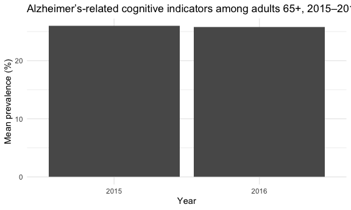

```r
az_nat_65_overall <- az_cog_65_overall |>
  group_by(year = year_start) |>
  summarise(
    mean_prev = mean(data_value, na.rm = TRUE),
    sd_prev   = sd(data_value, na.rm = TRUE),
    .groups = "drop"
  )

az_nat_65_overall |>
  mutate(year = factor(year)) |>
  ggplot(aes(x = year, y = mean_prev)) +
  geom_col() +
  labs(
    x = "Year",
    y = "Mean prevalence (%)",
    title = "Alzheimer’s-related cognitive indicators among adults 65+, 2015–2016"
  )
```

At the national level, the mean prevalence of Alzheimer’s-related cognitive indicators among adults aged 65+ was very similar in 2015 (26.0%) and 2016 (25.8%). The small difference of 0.2 percentage points is well within the between-state variation and does not suggest any clear change over this two-year period.

### prevelance ~ age

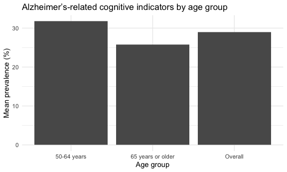

```r
az_age_desc <- az_cog_summary_base |>
  group_by(age_group) |>
  summarise(
    n_obs      = n(),
    mean_value = mean(data_value, na.rm = TRUE),
    .groups = "drop"
  )

ggplot(az_age_desc,
       aes(x = age_group, y = mean_value)) +
  geom_col() +
  labs(
    x = "Age group",
    y = "Mean prevalence (%)",
    title = "Alzheimer’s-related cognitive indicators by age group"
  )
```

Across all cognitive items, the mean prevalence was about 31.8% among adults aged 50–64 years and 25.8% among those aged 65 years or older.

### prevelance ~ sex

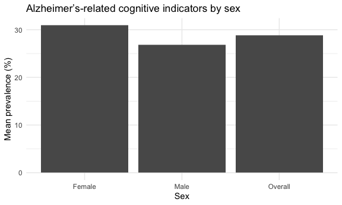

```r
az_sex_desc <- az_cog_summary_base |>
  group_by(sex_group) |>
  summarise(
    n_obs      = n(),
    mean_value = mean(data_value, na.rm = TRUE),
    .groups = "drop"
  )

ggplot(az_sex_desc,
       aes(x = sex_group, y = mean_value)) +
  geom_col() +
  labs(
    x = "Sex",
    y = "Mean prevalence (%)",
    title = "Alzheimer’s-related cognitive indicators by sex"
  )
```

Across all states and cognitive items in 2015–2016, women had a higher mean prevalence of Alzheimer’s-related cognitive indicators than men (30.9% vs 26.8%), suggesting a consistently greater reported cognitive burden among female respondents.

## Income Effects

### data import

```r
inc15 <- read_csv("data/median income-2015.csv", skip = 1) |>
  janitor::clean_names() |>
  transmute(
    year = 2015,
    state_name = geographic_area_name,
    median_income = as.numeric(median_income_dollars_estimate_households)
  )
```

[output not shown]

```r
inc16 <- read_csv("data/median income-2016.csv", skip = 1) |>
  janitor::clean_names() |>
  transmute(
    year = 2016,
    state_name = geographic_area_name,
    median_income = as.numeric(median_income_dollars_estimate_households)
  )
```

[output not shown]

```r
income_state <- bind_rows(inc15, inc16)
```

### income by state

```r
income_state_with_state <- income_state |>
  mutate(
    state = str_squish(str_extract(state_name, "[^,]+$")))

income_state_level <- income_state_with_state |>
  group_by(year, state) |>
  summarise(
    n_counties = n(),
    median_income_state = median(median_income, na.rm = TRUE),
    .groups = "drop"
  )

income_state_level <- income_state_with_state |>
  group_by(year, state) |>
  summarise(
    n_counties = n(),
    median_state = median(median_income, na.rm = TRUE),
    mean_state   = mean(median_income, na.rm = TRUE),
    .groups = "drop"
  )

income_state_level |> head(10)
```

```
## # A tibble: 10 × 5
##     year state                n_counties median_state mean_state
##    <dbl> <chr>                     <int>        <dbl>      <dbl>
##  1  2015 Alabama                      21       43553      46460.
##  2  2015 Alaska                        3       76427      76021.
##  3  2015 Arizona                      10       45195      44712.
##  4  2015 Arkansas                     11       46070      45950.
##  5  2015 California                   40       58954      62095.
##  6  2015 Colorado                     12       65960.     67584.
##  7  2015 Connecticut                   8       70144.     72854.
##  8  2015 Delaware                      3       56778      59366.
##  9  2015 District of Columbia          1       75628      75628
## 10  2015 Florida                      40       49466.     49624.
```

```r
state_vec <- unique(income_state_level$state)

az_cog_65_overall_state <- az_cog_65_overall |>
  filter(
    year_start %in% c(2015, 2016),
    sex_group == "Overall",
    location_desc %in% state_vec
  )

az_income <- az_cog_65_overall_state |>
  left_join(
    income_state_level,
    by = c("year_start" = "year",
           "location_desc" = "state")
  )
```

### relationship

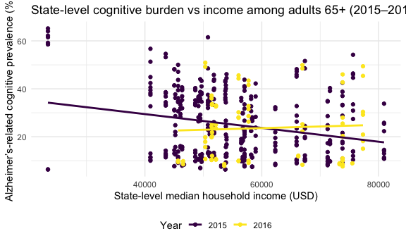

```r
ggplot(az_income,
       aes(x = median_state, y = data_value,
           color = factor(year_start))) +
  geom_point() +
  geom_smooth(method = "lm", se = FALSE) +
  labs(
    x = "State-level median household income (USD)",
    y = "Alzheimer’s-related cognitive prevalence (%)",
    color = "Year",
    title = "State-level cognitive burden vs income among adults 65+ (2015–2016)"
  )
```

```r
model_inc <- lm(
  data_value ~ median_state + factor(year_start),
  data = az_income
)

summary(model_inc)
```

```
##
## Call:
## lm(formula = data_value ~ median_state + factor(year_start),
##     data = az_income)
##
## Residuals:
##     Min      1Q  Median      3Q     Max
## -26.243 -12.189  -1.897   9.829  35.404
##
## Coefficients:
##                          Estimate Std. Error t value Pr(>|t|)
## (Intercept)             3.805e+01  3.260e+00  11.672  < 2e-16 ***
## median_state           -2.354e-04  5.762e-05  -4.085 5.25e-05 ***
## factor(year_start)2016 -2.920e-01  1.723e+00  -0.169    0.866
## ---
## Signif. codes:  0 '***' 0.001 '**' 0.01 '*' 0.05 '.' 0.1 ' ' 1
##
## Residual standard error: 13.32 on 431 degrees of freedom
## Multiple R-squared:  0.03882,    Adjusted R-squared:  0.03436
## F-statistic: 8.704 on 2 and 431 DF,  p-value: 0.0001968
```

Although higher state-level income was statistically associated with lower Alzheimer’s-related cognitive prevalence, income explained only a small share of the between-state variability. Several factors may contribute to this weak relationship. First, the analysis is ecological: each observation is an aggregated state–year estimate, so large within-state differences in income and cognitive health are not captured, and any individual-level association is diluted. Second, both cognitive burden and income are measured with error (self-reported survey indicators and ACS estimates), and we further aggregated county-level income up to the state level, which may introduce additional noise. Third, we only examined two years (2015–2016), over which variation in both income and prevalence is fairly modest. Finally, many other state-level determinants—such as education, health care access, demographic composition, and prevalence of vascular risk factors—were not adjusted for, so income alone is unlikely to account for the wide variation in cognitive outcomes across states.

## Education Effects

### data import

```r
edu15_raw <- read_csv("data/education2015.csv", skip = 1) |>
  janitor::clean_names()
```

[output not shown]

```r
edu15_state <- edu15_raw |>
  filter(!str_detect(geographic_area_name, ","))

edu16_raw <- read_csv("data/education2016.csv", skip = 1) |>
  janitor::clean_names()
```

[output not shown]

```r
edu16_state <- edu16_raw |>
  filter(!str_detect(geographic_area_name, ","))
```

We used the proportion of adults aged 25 years and older with a bachelor’s degree or higher as our main education indicator. This measure is commonly reported in the ACS and captures individuals who have completed at least a four-year college education, which is often used as a marker of higher socioeconomic status and cognitive reserve in the literature. Compared with more detailed education categories, using “bachelor’s degree or higher” gives a simple, comparable summary of educational attainment across states and years.

```r
edu15_state_slim <- edu15_state |>
  transmute(
    year = 2015,
    state = geographic_area_name,
    educ_bach = as.numeric(percent_estimate_percent_bachelors_degree_or_higher)
  )

edu16_state_slim <- edu16_state |>
  transmute(
    year = 2016,
    state = geographic_area_name,
    educ_bach = as.numeric(percent_estimate_percent_bachelors_degree_or_higher)
  )

edu_state <- bind_rows(edu15_state_slim, edu16_state_slim)
```

```r
az_edu <- az_cog_65_overall_state |>
  left_join(
    edu_state,
    by = c(
      "year_start" = "year",
      "location_desc" = "state"
    ))
```

### relationship analysis

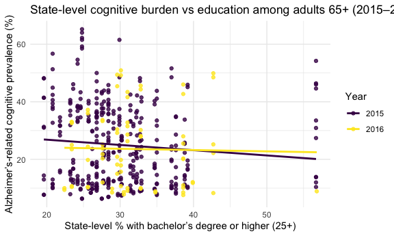

```r
ggplot(az_edu,
       aes(x = educ_bach,
           y = data_value,
           color = factor(year_start))) +
  geom_point(alpha = 0.8) +
  geom_smooth(method = "lm", se = FALSE) +
  labs(
    x = "State-level % with bachelor’s degree or higher (25+)",
    y = "Alzheimer’s-related cognitive prevalence (%)",
    color = "Year",
    title = "State-level cognitive burden vs education among adults 65+ (2015–2016)"
  ) +
  theme_minimal()
```

```r
model_edu <-
  lm(
  data_value ~ educ_bach + factor(year_start),
  data = az_edu)

summary(model_edu)
```

```
##
## Call:
## lm(formula = data_value ~ educ_bach + factor(year_start), data = az_edu)
##
## Residuals:
##     Min      1Q  Median      3Q     Max
## -19.554 -12.737  -2.077  10.376  39.346
##
## Coefficients:
##                        Estimate Std. Error t value Pr(>|t|)
## (Intercept)            29.87275    2.95268  10.117   <2e-16 ***
## educ_bach              -0.16205    0.09617  -1.685   0.0927 .
## factor(year_start)2016 -1.13543    1.73643  -0.654   0.5135
## ---
## Signif. codes:  0 '***' 0.001 '**' 0.01 '*' 0.05 '.' 0.1 ' ' 1
##
## Residual standard error: 13.53 on 431 degrees of freedom
## Multiple R-squared:  0.008142,   Adjusted R-squared:  0.003539
## F-statistic: 1.769 on 2 and 431 DF,  p-value: 0.1717
```

## Alzheimer’s outcomes at state-year level

```r
az_state_year <- az_cog_65_overall |>
  filter(
    year_start %in% c(2015, 2016),
    sex_group == "Overall"
  ) |>
  group_by(
    year       = year_start,
    state_abbr = location_abbr,
    state_name = location_desc
  ) |>
  summarise(
    mean_prev = mean(data_value, na.rm = TRUE),
    .groups = "drop"
  )

head(az_state_year)
```

```
## # A tibble: 6 × 4
##    year state_abbr state_name           mean_prev
##   <int> <chr>      <chr>                    <dbl>
## 1  2015 AL         Alabama                   30.2
## 2  2015 AR         Arkansas                  27.6
## 3  2015 AZ         Arizona                   23.4
## 4  2015 CA         California                25.7
## 5  2015 CO         Colorado                  22.8
## 6  2015 DC         District of Columbia      30.3
```

## Air Pollution Effects

### Data import

```r
air15 <- read_csv("data/clean_air_state_2015.csv")
air16 <- read_csv("data/clean_air_state_2016.csv")
air_state <- bind_rows(air15, air16)

air_state |> head()
```

```
## # A tibble: 6 × 4
##   state_abbr n_counties pm25_wtd_mean  year
##   <chr>           <dbl>         <dbl> <dbl>
## 1 AK                  5         10.3   2015
## 2 AL                 18          9.02  2015
## 3 AR                 11          8.82  2015
## 4 AZ                 13          7.7   2015
## 5 CA                 51          9.83  2015
## 6 CO                 26          6.38  2015
```

We used state-level fine particulate matter (PM2.5) concentrations as our primary indicator of air pollution. Specifically, we relied on the 24-hour weighted mean PM2.5 values derived from EPA AirData annual summary reports. These data were originally reported at the county level and then aggregated to obtain state–year averages for 2015 and 2016, matching the years available in the CDC Healthy Aging cognitive dataset.

```r
air_state_level <- air_state |>
  group_by(year, state_abbr) |>
  summarise(
    pm25_state = mean(pm25_wtd_mean, na.rm = TRUE),
    .groups = "drop"
  )

air_state_level |> head(10)
```

```
## # A tibble: 10 × 3
##     year state_abbr pm25_state
##    <dbl> <chr>           <dbl>
##  1  2015 AK              10.3
##  2  2015 AL               9.02
##  3  2015 AR               8.82
##  4  2015 AZ               7.7
##  5  2015 CA               9.83
##  6  2015 CO               6.38
##  7  2015 CT               8.1
##  8  2015 DE               8.57
##  9  2015 FL               6.54
## 10  2015 GA               9.02
```

### merge with Alzheimer’s outcomes

```r
az_cog_65_overall_state <- az_cog_65_overall |>
  filter(
    year_start %in% c(2015, 2016),
    sex_group == "Overall"
  )

az_air <- az_cog_65_overall_state |>
  left_join(
    air_state_level,
    by = c(
      "year_start"    = "year",
      "location_abbr" = "state_abbr"
    )
  )

az_air |>
  select(year_start, location_desc, pm25_state, data_value) |>
  head(10)
```

```
##    year_start        location_desc pm25_state data_value
## 1        2015 District of Columbia         NA       46.4
## 2        2015              Alabama   9.021429       36.8
## 3        2015             Colorado   6.377778       19.6
## 4        2015              Alabama   9.021429       12.5
## 5        2015              Georgia   9.025000       37.5
## 6        2015               Hawaii   6.725000       15.1
## 7        2015                 Iowa   8.415385        9.8
## 8        2015             Colorado   6.377778       10.5
## 9        2015              Alabama   9.021429       33.4
## 10       2015              Arizona   7.700000       20.7
```

### relationship analysis

```
## Warning: Removed 187 rows containing non-finite outside the scale range
## (`stat_smooth()`).

## Warning: Removed 187 rows containing missing values or values outside the
## scale range (`geom_point()`).
```

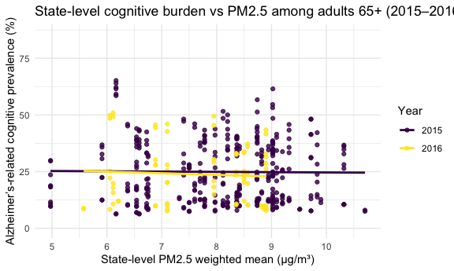

```r
ggplot(az_air,
       aes(x = pm25_state,
           y = data_value,
           color = factor(year_start))) +
  geom_point(alpha = 0.8) +
  geom_smooth(method = "lm", se = FALSE) +
  labs(
    x = "State-level PM2.5 weighted mean (µg/m³)",
    y = "Alzheimer’s-related cognitive prevalence (%)",
    color = "Year",
    title = "State-level cognitive burden vs PM2.5 among adults 65+ (2015–2016)"
  ) +
  theme_minimal()
```

```r
model_air <- lm(
  data_value ~ pm25_state + factor(year_start),
  data = az_air
)

summary(model_air)
```

```
##
## Call:
## lm(formula = data_value ~ pm25_state + factor(year_start), data = az_air)
##
## Residuals:
##     Min      1Q  Median      3Q     Max
## -18.972 -12.651  -2.391  10.294  39.928
##
## Coefficients:
##                        Estimate Std. Error t value Pr(>|t|)
## (Intercept)             26.5460     4.4889   5.914 6.95e-09 ***
## pm25_state              -0.2067     0.5494  -0.376    0.707
## factor(year_start)2016  -1.1602     1.7507  -0.663    0.508
## ---
## Signif. codes:  0 '***' 0.001 '**' 0.01 '*' 0.05 '.' 0.1 ' ' 1
##
## Residual standard error: 13.49 on 419 degrees of freedom
##   (187 observations deleted due to missingness)
## Multiple R-squared:  0.001254,   Adjusted R-squared:  -0.003514
## F-statistic: 0.263 on 2 and 419 DF,  p-value: 0.7689
```

In a linear regression of state-level Alzheimer’s-related cognitive prevalence on PM2.5 and survey year, we did not observe a clear association between air pollution and cognitive burden among adults aged 65+. The estimated coefficient for PM2.5 was $\hat\beta_{\text{PM2.5}} =$ -0.207, meaning that a 1–µg/m³ increase in the state-level PM2.5 weighted mean was associated with an estimated -0.207–percentage-point change in Alzheimer’s-related cognitive prevalence. A 10–µg/m³ difference in PM2.5 would therefore correspond to roughly -2.07 percentage points. However, this association was small and not statistically significant (p = 0.707), indicating that PM2.5 is not a strong predictor of between-state differences in cognitive burden in this model.

The coefficient for survey year (2016 vs 2015) was $\hat\beta_{\text{year}} =$ -1.16 with p = 0.508, suggesting no meaningful overall change in prevalence between the two years after accounting for PM2.5. The model $R^2$ was only 0.001, implying that PM2.5 and year together explain only a negligible fraction of the substantial between-state variation in Alzheimer’s-related cognitive outcomes. This is not surprising given the ecological nature of the analysis (state-level averages), potential measurement error in both pollution and cognitive indicators, the short two-year time window, and the absence of other important determinants such as income, education, demographics, and health care access.

## Mapping Alzheimer’s-related Cognitive Burden

### State-level choropleth map for 2015

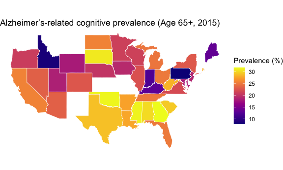

```r
library(maps)
library(stringr)

az_2015 = az_state_year |>
  filter(year == 2015)

us_map = map_data("state") |> as_tibble()

az_map_2015 = az_2015 |>
  mutate(region = str_to_lower(state_name)) |>
  inner_join(us_map, by = "region")

ggplot(az_map_2015,
       aes(long, lat, group = group, fill = mean_prev)) +
  geom_polygon(color = "white", linewidth = 0.2) +
  coord_fixed(1.3) +
  scale_fill_viridis_c(option = "C") +
  labs(
    title = "Alzheimer’s-related cognitive prevalence (Age 65+, 2015)",
    fill  = "Prevalence (%)"
  ) +
  theme_void() +
  theme(legend.position = "right")
```

### State-level choropleth map for 2016

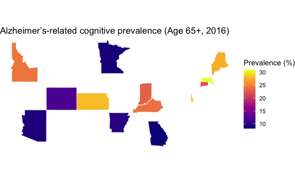

```r
library(maps)
library(stringr)

az_2016 = az_state_year |>
  filter(year == 2016)

us_map = map_data("state") |> as_tibble()

az_map_2016 = az_2016 |>
  mutate(region = str_to_lower(state_name)) |>
  inner_join(us_map, by = "region")

ggplot(az_map_2016,
       aes(long, lat, group = group, fill = mean_prev)) +
  geom_polygon(color = "white", linewidth = 0.2) +
  coord_fixed(1.3) +
  scale_fill_viridis_c(option = "C") +
  labs(
    title = "Alzheimer’s-related cognitive prevalence (Age 65+, 2016)",
    fill  = "Prevalence (%)"
  ) +
  theme_void() +
  theme(legend.position = "right")
```

### Side-by-side Comparison (2015 vs 2016)

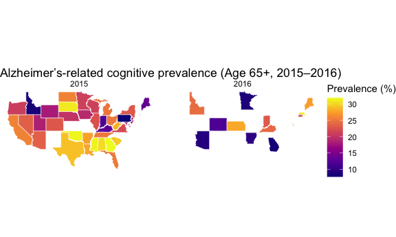

```r
az_15_16 = az_state_year |>
  filter(year %in% c(2015, 2016))

us_map = map_data("state") |> as_tibble()

az_map_15_16 = az_15_16 |>
  mutate(region = str_to_lower(state_name)) |>
  inner_join(us_map, by = "region")

ggplot(az_map_15_16,
       aes(long, lat, group = group, fill = mean_prev)) +
  geom_polygon(color = "white", linewidth = 0.2) +
  coord_fixed(1.3) +
  scale_fill_viridis_c(option = "C") +
  labs(
    title = "Alzheimer’s-related cognitive prevalence (Age 65+, 2015–2016)",
    fill  = "Prevalence (%)"
  ) +
  theme_void() +
  theme(legend.position = "right") +
  facet_wrap(~ year)
```